# Climate take 3

```r
library(tidyverse)
```

THINK ABOUT library(wbstats) and https://cengel.github.io/gearup2016/SULdataAccess.html AND: https://github.com/ropensci/rWBclimate

problems were missing data in the WorldBank set re-downloading them

###About the data

Upon much work it looks like can’t get the data via API request. (https://datahelpdesk.worldbank.org/knowledgebase/articles/902061-climate-data-api) The reason for this is that for the API can only either get Yearly averages or the avg monthly TAS (for the time span)

ALSO< note that for a lot of the data TAS is estaimted. “he Climate Data API provides access to historical temperature and precipitation data. These data are separate from the outputs of the GCMs, and they are based on gridded climatologies from the Climate Research Unit. Again, note that these data are proxies for temperature and precipitation, where modeling has been used to extrapolate estimates where instrumental (station) data were unavailable or unreliable, especially in the early 1900’s.”

for the data from the word bank (http://sdwebx.worldbank.org/climateportal/index.cfm?page=downscaled_data_download&menu=historical) can only get 30 countries at a time.

“This gridded historical dataset is derived from observational data, and provides quality controlled temperature and rainfall values from thousands of weather stations worldwide, as well as derivative products including monthly climatologies and long term historical climatologies. The dataset is produced by the Climatic Research Unit (CRU) of University of East Anglia (UEA), and reformatted by International Water Management Institute (IWMI). CRU-(Gridded Product). CRU data can be mapped to show the baseline climate and seasonality by month, for specific years, and for rainfall and temperature.”

TAS= near surface monthly mean air temperature (tas),

first, read data into R and calculate values

```r
my_data <- read_csv("fix_world_bank.csv")
```

https://datahelpdesk.worldbank.org/knowledgebase/articles/902061-climate-data-api https://www.r-bloggers.com/accessing-apis-from-r-and-a-little-r-programming/ https://www.programmableweb.com/news/how-to-access-any-restful-api-using-r-language/how-to/2017/07/21

```r
#http://climatedataapi.worldbank.org/climateweb/rest/v1/country/mavg/tas/2020/2039/afg

require("httr")
#This package makes requesting data from just about any API easier by formatting your GET requests with the proper headers and authentications. Next, install jsonlite in your script:
require("jsonlite")
library(tidyverse)

url <- "http://climatedataapi.worldbank.org/climateweb/rest/v1/country/mavg/tas/2020/2039/afg"
path <- "eurlex/directory_code"
raw.result <- GET(url = url, path = path)
names(raw.result)

this.raw.content <- rawToChar(raw.result$content)
```

ok, now we want something different. 1. get the higset 3 values for a month 2. get the lowest 3 values for a month

then max year 1 - max year 2 and min year 1 - min year 2

| Country | Year | Mean_min | change_from_last_year |
| --- | --- | --- | --- |
| ABW | 1901 | 26.71903333 | NA |
| ABW | 1902 | 26.68263333 | -3.640000e-02 |
| ABW | 1903 | 26.68230000 | -3.333333e-04 |
| ABW | 1904 | 26.49886667 | -1.834333e-01 |
| ABW | 1905 | 26.52423333 | 2.536667e-02 |
| ABW | 1906 | 26.39246667 | -1.317667e-01 |
| ABW | 1907 | 26.16973333 | -2.227333e-01 |
| ABW | 1908 | 26.55310000 | 3.833667e-01 |
| ABW | 1909 | 26.29430000 | -2.588000e-01 |
| ABW | 1910 | 26.27726667 | -1.703333e-02 |

[output cut: 990 more lines]

ok so now i have a databale to the avg max change and avg min change for each country and year

Next i want to join the tables together?

```r
all_things <- left_join(avg_min_change, avg_max_change)
```

#update 2019-05-14: i need to look this over more and see what is going on. why did i subset out this data? also note that my_data is used here too!

| Year | Month | Country | n |
| --- | --- | --- | --- |
| 1901 | 1 | ABW | 1 |
| 1901 | 1 | AFG | 1 |
| 1901 | 1 | AGO | 1 |
| 1901 | 1 | AIA | 1 |
| 1901 | 1 | ALB | 1 |
| 1901 | 1 | AND | 1 |
| 1901 | 1 | ANT | 1 |
| 1901 | 1 | ARE | 1 |
| 1901 | 1 | ARG | 1 |
| 1901 | 1 | ARM | 1 |

[output cut: 990 more lines]

ok, i want to add country names to the values_RMS2 set BELOW is using another list. maybe use the better one?

```r
names <- read_csv("Country_iso.csv")
values_RMS_edited <- values_RMS2 %>% rename(`Alpha-3_code` = Country)
left_join(values_RMS_edited, names)
values_temp <- left_join(values_RMS_edited, names)
#check to see didn't loose data
dim(values_RMS_edited)
dim(values_temp)
#somethign wonky....look at the country_iso list
values_total <- values_temp
write_csv(values_total, "world_bank_TAS_with_country_names.csv")
```

fixing issues using Countrycode package:

Arel-Bundock, Vincent, Nils Enevoldsen, and CJ Yetman, (2018). countrycode: An R package to convert country names and country codes. Journal of Open Source Software, 3(28), 848, https://doi.org/10.21105/joss.00848

```r
library(countrycode)
```

I probbaly should redo all of this above in a cleaner manner to make sure it is good

```r
my_join3 <- all_things %>% ungroup() %>%  mutate(iso3c = Country) %>% select(-Country) %>% inner_join(my_join, by=c("iso3c", "Year"))
```

```
Error in tbl_vars(y) : object 'my_join' not found
```

test it

| Country | Year | RMS | iso3c | continent | country.name.en | iso.name.en | region |
| --- | --- | --- | --- | --- | --- | --- | --- |
| MRT | 1910 | 0.6424062 | MRT | Africa | Mauritania | Mauritania | Western Africa |

#now, we need the DCI values back!

| Country.x | Year | RMS | iso3c | continent | country.name.en | iso.name.en | region | stateabb | ccode | Country.y | milex | milper | tpop | milper_1 | P | W | X |
| --- | --- | --- | --- | --- | --- | --- | --- | --- | --- | --- | --- | --- | --- | --- | --- | --- | --- |
| ABW | 1901 | 0.2689519 | ABW | Americas | Aruba | Aruba | Caribbean | NA | NA | NA | NA | NA | NA | NA | NA | NA | NA |
| ABW | 1902 | 0.3756172 | ABW | Americas | Aruba | Aruba | Caribbean | NA | NA | NA | NA | NA | NA | NA | NA | NA | NA |
| ABW | 1903 | 0.2943593 | ABW | Americas | Aruba | Aruba | Caribbean | NA | NA | NA | NA | NA | NA | NA | NA | NA | NA |
| ABW | 1904 | 0.4719042 | ABW | Americas | Aruba | Aruba | Caribbean | NA | NA | NA | NA | NA | NA | NA | NA | NA | NA |
| ABW | 1905 | 0.3231945 | ABW | Americas | Aruba | Aruba | Caribbean | NA | NA | NA | NA | NA | NA | NA | NA | NA | NA |
| ABW | 1906 | 0.3568431 | ABW | Americas | Aruba | Aruba | Caribbean | NA | NA | NA | NA | NA | NA | NA | NA | NA | NA |
| ABW | 1907 | 0.4593058 | ABW | Americas | Aruba | Aruba | Caribbean | NA | NA | NA | NA | NA | NA | NA | NA | NA | NA |
| ABW | 1908 | 0.2910771 | ABW | Americas | Aruba | Aruba | Caribbean | NA | NA | NA | NA | NA | NA | NA | NA | NA | NA |
| ABW | 1909 | 0.4517025 | ABW | Americas | Aruba | Aruba | Caribbean | NA | NA | NA | NA | NA | NA | NA | NA | NA | NA |
| ABW | 1910 | 0.5050143 | ABW | Americas | Aruba | Aruba | Caribbean | NA | NA | NA | NA | NA | NA | NA | NA | NA | NA |

[output cut: 105 more lines]

#ok, data analysis time

what is the relastionship between DCI and other values like RMS

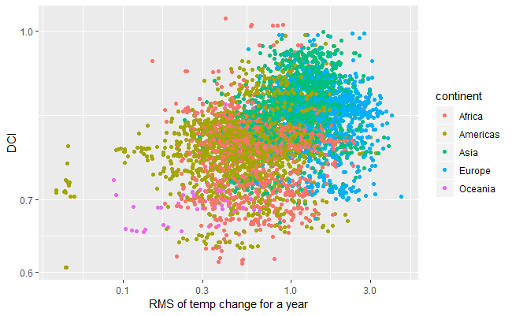

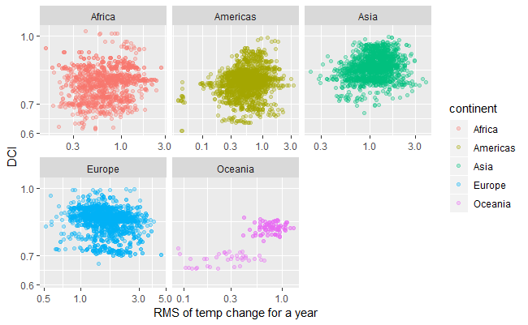